# Reproducible research: Peer Assignment: 1

The code requires the file **activity.zip** in the working directory.

## Loading and preprocessing the data

```r
library(dplyr)
if (!file.exists("activity.csv")) {unzip("activity.zip")} # unzip only if not done yet

activity<-read.csv("activity.csv", header=TRUE, na="NA")
activity$date<-as.Date(activity$date) # change format of date values
activity$steps<-as.numeric(activity$steps) # change format of date values
activity$interval<-as.numeric(activity$interval) # change format of date values
head(activity)
```

```
##   steps       date interval
## 1    NA 2012-10-01        0
## 2    NA 2012-10-01        5
## 3    NA 2012-10-01       10
## 4    NA 2012-10-01       15
## 5    NA 2012-10-01       20
## 6    NA 2012-10-01       25
```

## What is mean total number of steps taken per day?

Missing values are ignored in this step. The histogram of the total number of steps taken each day:

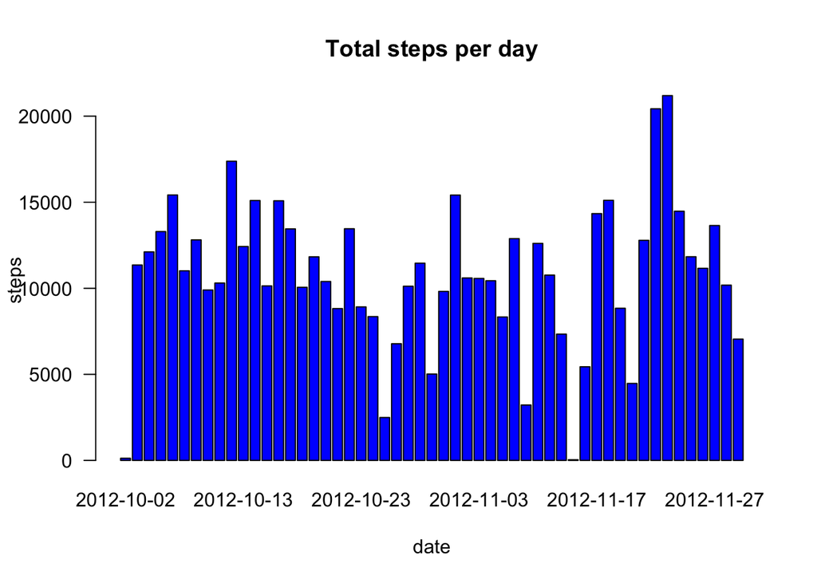

```r
activity_day<-aggregate(steps ~ date, activity, sum)
barplot(activity_day$steps, names.arg=activity_day$date,las=1,main="Total steps per day", srt = 60,xlab="date", ylab="steps", col="blue")
```

Calculated mean and median total number of steps taken per day:

```r
mean(activity_day$steps, na.rm=TRUE) # mean
```

```
## [1] 10766
```

```r
median(activity_day$steps, na.rm=TRUE) # median
```

```
## [1] 10765
```

Time series plot of 5-minute interval (x-axis) and the average number of steps taken.

## What is the average daily activity pattern?

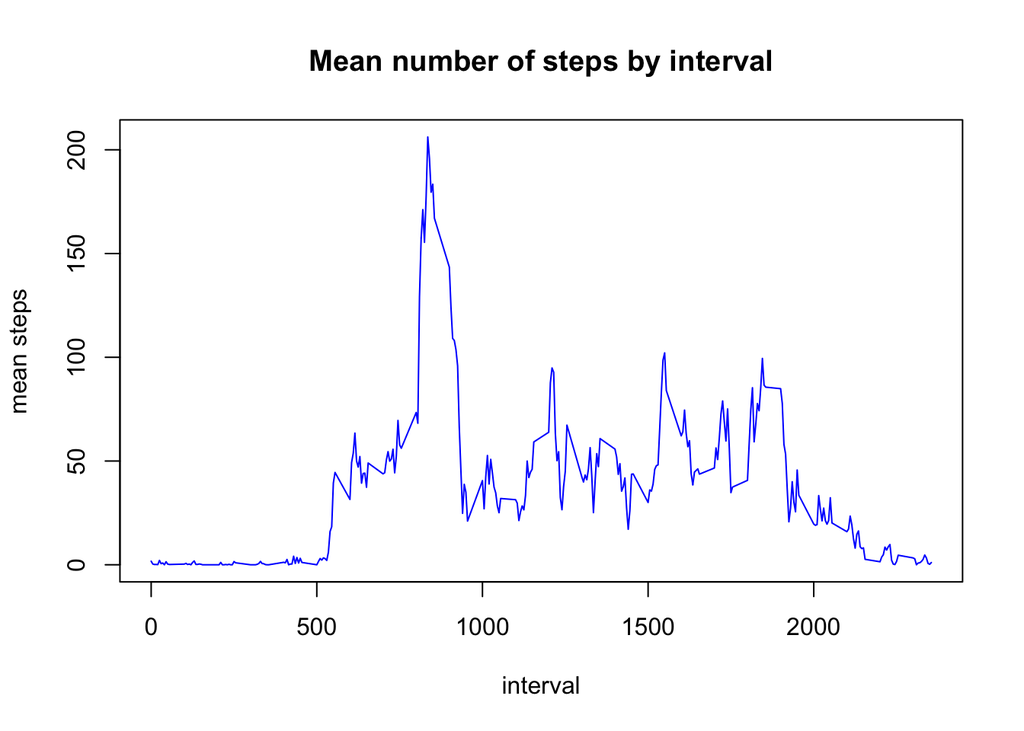

```r
activity_ts<-activity %.% group_by(interval) %.% summarise(meanInterval = mean(steps, na.rm=TRUE))
plot(activity_ts, type="l", main="Mean number of steps by interval", srt = 60,xlab="interval", ylab="mean steps", col="blue")
```

Which 5-minute interval, on average across all the days in the dataset, contains the maximum number of steps?

```r
activity_ts[which.max(activity_ts$meanInterval),1]
```

```
## [1] 835
```

## Imputing missing values

Calculate and report the total number of missing values in the dataset. Then, create a new data frame based on the original activity data by filling the missing values with the mean as calculated above for the interval plot.

```r
sum(!complete.cases(activity$steps))
```

```
## [1] 2304
```

```r
activity_filled <- activity
n<-nrow(activity)
for (r in 1:n) {
    if (is.na(activity_filled$steps[r]))
        {
            activity_filled$steps[r]<-activity_ts$meanInterval[activity_ts$interval==activity$interval[r]]
        }
}
```

Make a histogram of the total number of steps taken each day and Calculate and report the mean and median total number of steps taken per day.

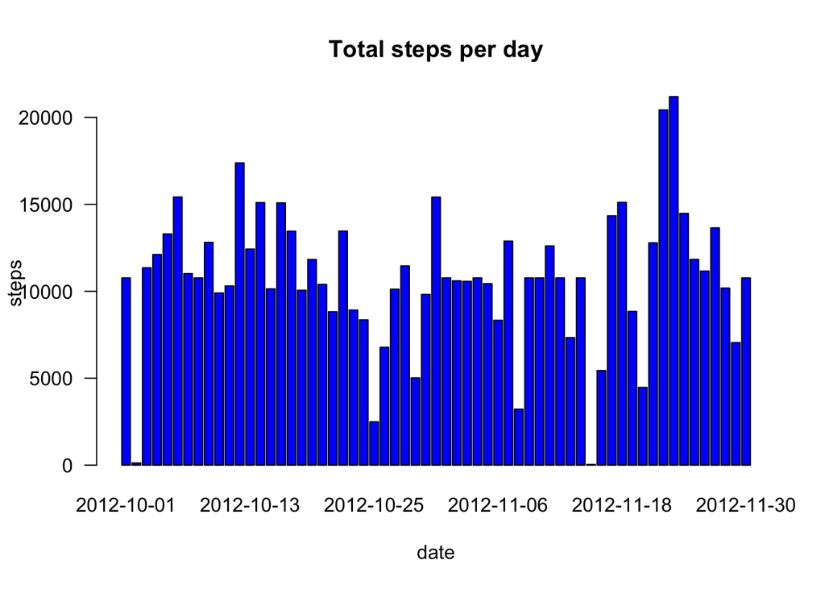

```r
activity_day_filled<-aggregate(steps ~ date, activity_filled, sum)
barplot(activity_day_filled$steps, names.arg=activity_day_filled$date,las=1,main="Total steps per day", srt = 60,xlab="date", ylab="steps", col="blue")
```

Calculated mean and median total number of steps taken per day:

```r
mean(activity_day_filled$steps) # mean
```

```
## [1] 10766
```

```r
median(activity_day_filled$steps) # median
```

```
## [1] 10766
```

The impcat using the above adjustment for NA’s is low.

```r
step_diff <- sum(activity_day$steps) - sum(activity_day_filled$steps)
```

## Are there differences in activity patterns between weekdays and weekends?

[figure not shown]

```r
week <- factor(weekdays(activity_filled$date) %in% c("Saturday","Sunday"),
               labels=c("weekday","weekend"))

activity_dayType <- aggregate(activity_filled$steps, by=list(interval=activity_filled$interval,
                                                             weekday=week), mean)

activity_weekend <- subset(activity_dayType,weekday=="weekday")
activity_weekday <- subset(activity_dayType,weekday=="weekend")


plot(activity_weekend$interval/max(activity_weekend$interval)*24,activity_weekend$x, type="l", col="blue", xlab="time", ylab="avg number of steps in each 5 min interval", lwd=3,xaxt = "n")
axis(1, at=0:24, labels=paste(0:24,":00", sep=""))

lines(activity_weekday$interval/max(activity_weekday$interval)*24, activity_weekday$x, col="red", lwd=3)

legend("topright",lty = c(1,1),
        col = c("blue", "red"),
        legend = c("weekend", "weekday"))
```

[figure not shown]

```r
par(mfrow=c(2,1))
plot(activity_weekend$interval/max(activity_weekend$interval)*24,activity_weekend$x, type="l", col="blue", xlab="time", ylab="steps", lwd=3,xaxt = "n", main="weekend")
axis(1, at=0:24, labels=paste(0:24,":00", sep=""))

plot(activity_weekday$interval/max(activity_weekday$interval)*24,activity_weekday$x, type="l", col="red", xlab="time", ylab="steps", lwd=3,xaxt = "n", main="weekday")
axis(1, at=0:24, labels=paste(0:24,":00", sep=""))
```